# STATS 506

Problem Set 2

Author

Sky Shi

Modified

September 26, 2024

The link to the problem set 2 GitHub repository is at: https://github.com/skyshi1/STAT506/tree/main/problemSet2, as a sub-folder of the STATS 506 repository.

## Problem 1 - Dice Game

### (a) Dice game with different methods

#### Version 1: Implement this game using a loop.

```r
#' Play the dice game using a loop.
#'
#' @param n Number of dice to roll
#' @return Total winnings from rolling `n` dice
play_dice_loop <- function(n) {
  winnings <- 0
  for (i in 1:n) {
    roll <- sample(1:6, 1)  # Roll a die
    if (roll == 3 || roll == 5) {
      winnings <- winnings + (2 * roll - 2)  # Win 2*roll-2 if roll 3 or 5
    } else {
      winnings <- winnings - 2  # Lose $2 on other rolls
    }
  }
  return(winnings)
}
```

#### Version 2: Implement this game using built-in R vectorized functions.

```r
#' Play the dice game using built-in R vectorized functions.
#'
#' @param n Number of dice to roll
#' @return Total winnings from rolling `n` dice
play_dice_vectorized <- function(n) {
  rolls <- sample(1:6, n, replace = TRUE)  # Vector of rolls
  winnings <- ifelse(rolls == 3 | rolls == 5, 2 * rolls - 2, -2)
  return(sum(winnings))  # Total winnings
}
```

#### Version 3: Implement this by rolling all the dice into one and collapsing the die rolls into a single table().

```r
#' Play the dice game using table to count rolls.
#'
#' @param n Number of dice to roll
#' @return Total winnings from rolling `n` dice
play_dice_table <- function(n) {
  rolls <- sample(1:6, n, replace = TRUE)
  roll_table <- table(rolls)  # Create a table of roll counts
  winnings <- 0

  if ("3" %in% names(roll_table)) winnings <- winnings + roll_table["3"] * (6 - 2)  # Win 6-2 if roll 3
  if ("5" %in% names(roll_table)) winnings <- winnings + roll_table["5"] * (10 - 2)  # Win 10-2 if roll 5
  losses <- n - sum(roll_table[names(roll_table) == "3" | names(roll_table) == "5"])
  winnings <- winnings - losses * 2  # Lose 2 for other rolls

  return(winnings)
}
```

#### Version 4: Implement this game by using one of the “apply” functions.

```r
#' Play the dice game using sapply,
#'
#' @param n Number of dice to roll
#' @return Total winnings from rolling `n` dice
play_dice_apply <- function(n) {
  rolls <- sample(1:6, n, replace = TRUE)
  winnings <- sapply(rolls, function(roll) {
    if (roll == 3 || roll == 5) {
      return(2 * roll - 2)  # Win 2*roll-2 if roll 3 or 5
    } else {
      return(-2)  # Lose 2 for other rolls
    }
  })
  return(sum(winnings))
}
```

### (b) Demonstrate all versions work

```r
# Test each version with input 3
cat("Results for n = 3\n")
```

```
Results for n = 3
```

```r
cat("Loop Version: ", play_dice_loop(3), "\n")
```

```
Loop Version:  4
```

```r
cat("Vectorized Version: ", play_dice_vectorized(3), "\n")
```

```
Vectorized Version:  4
```

```r
cat("Table Version: ", play_dice_table(3), "\n")
```

```
Table Version:  10
```

```r
cat("Apply Version: ", play_dice_apply(3), "\n")
```

```
Apply Version:  6
```

```r
# Test again
cat("\nAgain, results for n = 3\n")
```

```
Again, results for n = 3
```

```r
cat("Loop Version: ", play_dice_loop(3), "\n")
```

```
Loop Version:  6
```

```r
cat("Vectorized Version: ", play_dice_vectorized(3), "\n")
```

```
Vectorized Version:  0
```

```r
cat("Table Version: ", play_dice_table(3), "\n")
```

```
Table Version:  0
```

```r
cat("Apply Version: ", play_dice_apply(3), "\n")
```

```
Apply Version:  -6
```

```r
# Test each version with input 3,000
cat("\nResults for n = 3000\n")
```

```
Results for n = 3000
```

```r
cat("Loop Version: ", play_dice_loop(3000), "\n")
```

```
Loop Version:  2134
```

```r
cat("Vectorized Version: ", play_dice_vectorized(3000), "\n")
```

```
Vectorized Version:  1488
```

```r
cat("Table Version: ", play_dice_table(3000), "\n")
```

```
Table Version:  1746
```

```r
cat("Apply Version: ", play_dice_apply(3000), "\n")
```

```
Apply Version:  1988
```

```r
# Test again
cat("\nAgain, results for n = 3000\n")
```

```
Again, results for n = 3000
```

```r
cat("Loop Version: ", play_dice_loop(3000), "\n")
```

```
Loop Version:  1740
```

```r
cat("Vectorized Version: ", play_dice_vectorized(3000), "\n")
```

```
Vectorized Version:  2102
```

```r
cat("Table Version: ", play_dice_table(3000), "\n")
```

```
Table Version:  1966
```

```r
cat("Apply Version: ", play_dice_apply(3000), "\n")
```

```
Apply Version:  1914
```

So our functions are working.

### (c) Demonstrate that the four versions give the same result

```r
# Check n=3 with seed 0.
cat("Results for n = 3 (with seed 0)\n")
```

```
Results for n = 3 (with seed 0)
```

```r
set.seed(0)
result_loop_3 <- play_dice_loop(3)
set.seed(0)
result_vectorized_3 <- play_dice_vectorized(3)
set.seed(0)
result_table_3 <- play_dice_table(3)
set.seed(0)
result_apply_3 <- play_dice_apply(3)

cat("Loop Version: ", result_loop_3, "\n")
```

```
Loop Version:  -6
```

```r
cat("Vectorized Version: ", result_vectorized_3, "\n")
```

```
Vectorized Version:  -6
```

```r
cat("Table Version: ", result_table_3, "\n")
```

```
Table Version:  -6
```

```r
cat("Apply Version: ", result_apply_3, "\n\n")
```

```
Apply Version:  -6
```

```r
# Check n=3 with seed 111.
cat("Results for n = 3 (with seed 111)\n")
```

```
Results for n = 3 (with seed 111)
```

```r
set.seed(111)
result_loop_3 <- play_dice_loop(3)
set.seed(111)
result_vectorized_3 <- play_dice_vectorized(3)
set.seed(111)
result_table_3 <- play_dice_table(3)
set.seed(111)
result_apply_3 <- play_dice_apply(3)

cat("Loop Version: ", result_loop_3, "\n")
```

```
Loop Version:  0
```

```r
cat("Vectorized Version: ", result_vectorized_3, "\n")
```

```
Vectorized Version:  0
```

```r
cat("Table Version: ", result_table_3, "\n")
```

```
Table Version:  0
```

```r
cat("Apply Version: ", result_apply_3, "\n\n")
```

```
Apply Version:  0
```

```r
# Check n=3000 with seed 0.
cat("Results for n = 3000 (with seed 0)\n")
```

```
Results for n = 3000 (with seed 0)
```

```r
set.seed(0)
result_loop_3000 <- play_dice_loop(3000)
set.seed(0)
result_vectorized_3000 <- play_dice_vectorized(3000)
set.seed(0)
result_table_3000 <- play_dice_table(3000)
set.seed(0)
result_apply_3000 <- play_dice_apply(3000)

cat("Loop Version: ", result_loop_3000, "\n")
```

```
Loop Version:  2208
```

```r
cat("Vectorized Version: ", result_vectorized_3000, "\n")
```

```
Vectorized Version:  2208
```

```r
cat("Table Version: ", result_table_3000, "\n")
```

```
Table Version:  2208
```

```r
cat("Apply Version: ", result_apply_3000, "\n\n")
```

```
Apply Version:  2208
```

```r
# Check n=3000 with seed 111.
cat("Results for n = 3000 (with seed 111)\n")
```

```
Results for n = 3000 (with seed 111)
```

```r
set.seed(111)
result_loop_3000 <- play_dice_loop(3000)
set.seed(111)
result_vectorized_3000 <- play_dice_vectorized(3000)
set.seed(111)
result_table_3000 <- play_dice_table(3000)
set.seed(111)
result_apply_3000 <- play_dice_apply(3000)

# Print results for n = 3000
cat("Loop Version: ", result_loop_3000, "\n")
```

```
Loop Version:  1918
```

```r
cat("Vectorized Version: ", result_vectorized_3000, "\n")
```

```
Vectorized Version:  1918
```

```r
cat("Table Version: ", result_table_3000, "\n")
```

```
Table Version:  1918
```

```r
cat("Apply Version: ", result_apply_3000, "\n")
```

```
Apply Version:  1918
```

We have checked the consistency of all the methods with 2 different seeds and 2 different n’s. We see that all methods provide the same result with the same randomizing seed.

### (d) Use the microbenchmark package to clearly demonstrate the speed of the implementations

```r
# Load the microbenchmark package
library(microbenchmark)

# Test performance with input size 1,000
benchmark_1000 <- microbenchmark(
  loop = play_dice_loop(1000),
  vectorized = play_dice_vectorized(1000),
  table = play_dice_table(1000),
  apply = play_dice_apply(1000),
  times = 1000  # Repeat the test 1000 times for better accuracy, so 1,000,000 in total
)

# Print results for n = 1,000
print(benchmark_1000)
```

```
Unit: microseconds
       expr      min        lq       mean    median        uq       max neval
       loop 3434.001 3602.9015 3980.50301 3699.2505 3949.7520 31997.001  1000
 vectorized   76.301   84.0020   96.19459   87.9000   98.3510   448.801  1000
      table  184.201  197.6505  227.46020  207.2010  230.8005  2235.901  1000
      apply  567.002  587.7015  649.54879  601.4505  641.4510  3188.501  1000
```

```r
# Test performance with input size 100,000
benchmark_100000 <- microbenchmark(
  loop = play_dice_loop(100000),
  vectorized = play_dice_vectorized(100000),
  table = play_dice_table(100000),
  apply = play_dice_apply(100000),
  times = 10  # Repeat the test 10 times for better accuracy, so 1,000,000 in total
)

# Print results for n = 100,000
print(benchmark_100000)
```

```
Unit: milliseconds
       expr        min         lq       mean     median         uq        max
       loop 393.858401 404.317401 427.829481 415.428300 444.318001 495.299701
 vectorized   7.355600   7.508002   8.284151   8.317901   8.941401   9.064101
      table   8.547701   9.521501   9.783721   9.738751  10.334302  11.085001
      apply  68.056000  69.910701  77.340041  73.759251  81.545401 100.065900
 neval
    10
    10
    10
    10
```

The following discussions are drawn from one of the runs, the exact values might change since I am re-running all the codes frequently, but the overall behaviors shouldn’t change.

Input Size: 1,000 Rolls:

- **Loop Version**: The slowest method, with a median time of 4663.50 us. Loops in R are not efficient.
- **Vectorized Version**: The fastest method, with a median time of 90.70 us. R’s vectorized operations are optimized.
- **Table Version**: Slower than vectorized, with a median time of 222.50 us. The `table()` function introduces less efficiency
- **Apply Version**: Slower than vectorized, with a median time of 623.55 us, might because `apply()` is iterative.

Input Size: 100,000 Rolls

### (e) Fair game?

```r
trials <- 1000000
n <- 1

# Run Monte Carlo simulation using the vectorized version
results <- replicate(trials, play_dice_vectorized(n))

# Calculate the expected average winnings
expected_winnings <- mean(results)

# Display the result
cat("Expected average winnings after 1,000,000 trials: ", expected_winnings, "\n")
```

```
Expected average winnings after 1,000,000 trials:  0.668438
```

## Problem 2 - Linear Regression

### (a) Rename the columns

```r
# Load the dataset
cars_data <- read.csv("cars.csv")

# Renaming the columns to have more reasonable lengths
colnames(cars_data) <- c(
    'Height',
    'Length',
    'Width',
    'Driveline',
    'Engine_Type',
    'Hybrid',
    'Forward_Gears',
    'Transmission',
    'City_MPG',
    'Fuel_Type',
    'Highway_MPG',
    'Classification',
    'ID',
    'Make',
    'Model',
    'Year',
    'Horsepower',
    'Torque'
)

# View the first few rows of the renamed dataset
head(cars_data)
```

```
  Height Length Width         Driveline
1    140    143   202   All-wheel drive
2    140    143   202 Front-wheel drive
3    140    143   202 Front-wheel drive
4    140    143   202   All-wheel drive
5    140    143   202   All-wheel drive
6     91     17    62   All-wheel drive
                                   Engine_Type Hybrid Forward_Gears
1         Audi 3.2L 6 cylinder 250hp 236ft-lbs   True             6
2 Audi 2.0L 4 cylinder 200 hp 207 ft-lbs Turbo   True             6
3 Audi 2.0L 4 cylinder 200 hp 207 ft-lbs Turbo   True             6
4 Audi 2.0L 4 cylinder 200 hp 207 ft-lbs Turbo   True             6
5 Audi 2.0L 4 cylinder 200 hp 207 ft-lbs Turbo   True             6
6        Audi 3.2L 6 cylinder 265hp 243 ft-lbs   True             6
                    Transmission City_MPG Fuel_Type Highway_MPG
```

[output cut: 20 more lines]

So we have renamed the columns. They are of nice sizes.

### (b) Restrict the data to cars whose Fuel Type is “Gasoline”

```r
# Restrict the data to cars whose Fuel Type is "Gasoline"
gasoline_cars <- cars_data[cars_data$Fuel_Type == "Gasoline", ]
```

I am creating a subset named “gasoline_cars”. I don’t like modifying on the original dataset directly.

### (c) Examine the distribution of highway gas mileage

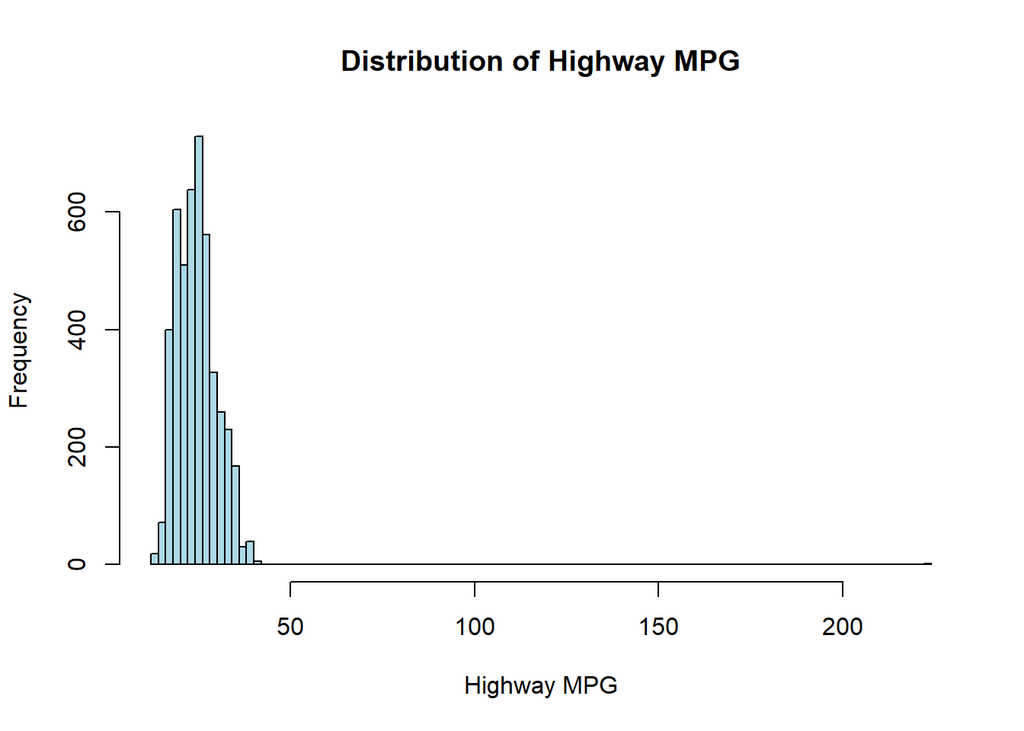

```r
# Examine the distribution of Highway MPG
hist(gasoline_cars$Highway_MPG,
     breaks = 100,
     main = "Distribution of Highway MPG",
     xlab = "Highway MPG",
     col = "lightblue",
     border = "black")
```

The raw distribution looks skewed, but we need to check it explicitly.

```r
# Find the skewness and decide whether to make transformations.
skewness <- mean((gasoline_cars$Highway_MPG - mean(gasoline_cars$Highway_MPG))^3) / sd(gasoline_cars$Highway_MPG)^3
cat("Skewness of Highway MPG:", skewness, "\n")
```

```
Skewness of Highway MPG: 7.990895
```

Yes, it is skewed.

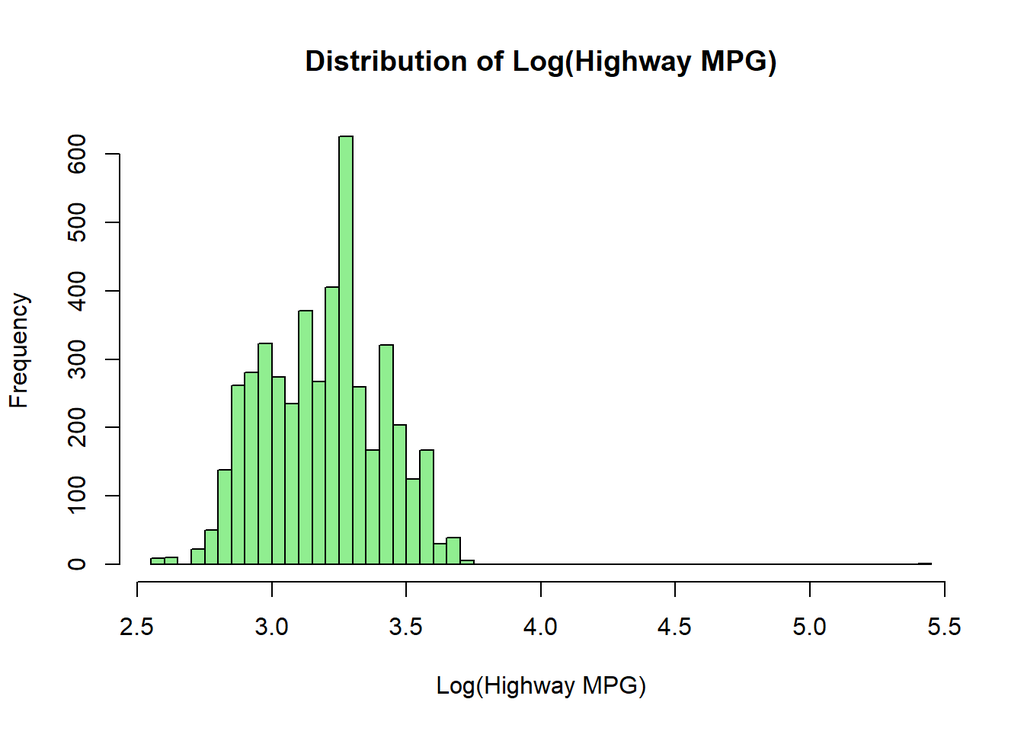

```
   Min. 1st Qu.  Median    Mean 3rd Qu.    Max.
  2.565   3.045   3.219   3.194   3.332   5.407
```

```r
# If skewness is high (greater than +2 or less than -2), consider a log transformation
if (skewness > 2 | skewness < -2) {
  gasoline_cars$log_Highway_MPG <- log(gasoline_cars$Highway_MPG)

  # Plot for the transformed variable
  hist(gasoline_cars$log_Highway_MPG,
       breaks = 100,
       main = "Distribution of Log(Highway MPG)",
       xlab = "Log(Highway MPG)",
       col = "lightgreen",
       border = "black")

  # If needed, add the transformed variable to go forward
  summary(gasoline_cars$log_Highway_MPG)
} else {
  cat("No transformation needed.\n")
}
```

Here from the codes, we see that the skewness is high, so we are using the log transformation **log-transformed Highway MPG** in the future. The log distribution looks more normal too.

### (d) Fit a linear regression model predicting MPG on the highway

```r
# Fit the linear regression model using the log-transformed Highway MPG
model_log <- lm(log_Highway_MPG ~ Torque + Horsepower + Height + Length + Width + Year, data = gasoline_cars)

# View the summary of the model
summary(model_log)
```

```
Call:
lm(formula = log_Highway_MPG ~ Torque + Horsepower + Height +
    Length + Width + Year, data = gasoline_cars)

Residuals:
     Min       1Q   Median       3Q      Max
-0.54207 -0.09294 -0.00562  0.09919  2.41249

Coefficients:
              Estimate Std. Error t value Pr(>|t|)
(Intercept) -5.340e+01  5.334e+00 -10.010  < 2e-16 ***
Torque      -2.306e-03  6.758e-05 -34.119  < 2e-16 ***
Horsepower   9.329e-04  6.988e-05  13.348  < 2e-16 ***
Height       4.020e-04  3.448e-05  11.657  < 2e-16 ***
Length       2.990e-05  2.711e-05   1.103 0.270066
Width       -9.178e-05  2.775e-05  -3.307 0.000949 ***
Year         2.830e-02  2.653e-03  10.667  < 2e-16 ***
---
Signif. codes:  0 '***' 0.001 '**' 0.01 '*' 0.05 '.' 0.1 ' ' 1

Residual standard error: 0.1413 on 4584 degrees of freedom
Multiple R-squared:  0.5625,    Adjusted R-squared:  0.5619
F-statistic: 982.1 on 6 and 4584 DF,  p-value: < 2.2e-16
```

In the fitted linear regression model , the coefficient for **Torque** is estimated to be **-0.002306**. Since the dependent variable is log-transformed, the coefficient of **Torque** can be interpreted as a percentage change: 1-unit increase in **Torque** is associated with ~0.23% decrease in **Highway MPG**, holding all other variables (Horsepower, Height, Length, Width, and Year) constant. This coefficient is statistically significant, with a p-value of **< 2e-16**, indicating a very low likelihood that the result is due to chance. This result aligns with the expectation that vehicles with higher torque usually have more powerful engines, which often consume more fuel, resulting in lower fuel efficiency. As a conclusion, from this linear regression model with **log-transformed Highway MPG**, the strong statistical significance confirms that **Torque** has a real, measurable effect on **Highway MPG**.

### (e) Refit the model

Find a good year first:

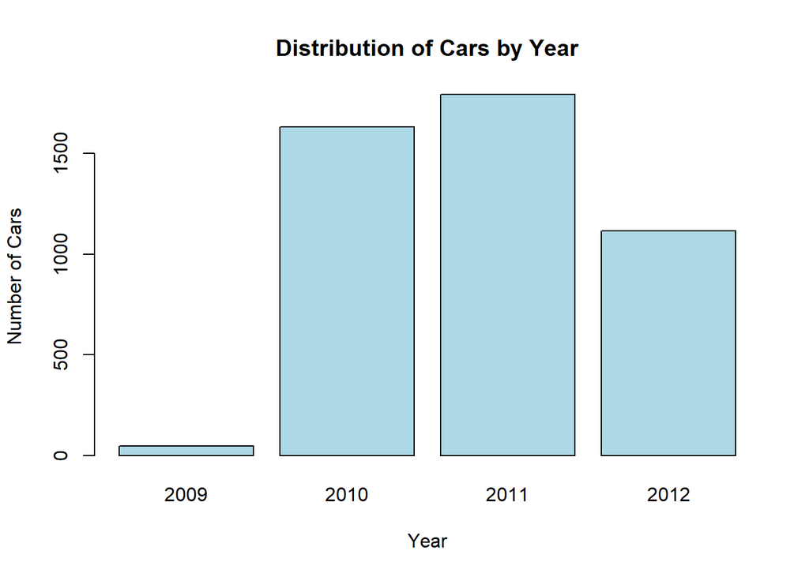

```r
# Create a bar plot of the distribution of Year to examine it.
barplot(table(gasoline_cars$Year),
        main = "Distribution of Cars by Year",
        xlab = "Year",
        ylab = "Number of Cars",
        col = "lightblue",
        border = "black")
```

```r
# Filter the dataset to only include cars from 2011
cars_2011 <- subset(gasoline_cars, Year == "2011")
```

Let’s choose the cars in 2011. Then let’s choose some HP:

```r
# Check the summary in the 2011 subset
summary(cars_2011$Horsepower)
```

```
   Min. 1st Qu.  Median    Mean 3rd Qu.    Max.
  100.0   185.0   268.0   273.7   324.8   638.0
```

I will use the 1st quartile, median, and the 3rd quartile for the main plot. Before the final plots, now we remove the outliers in torque.

```r
# Overview of distribution
summary(cars_2011$Torque)
```

```
   Min. 1st Qu.  Median    Mean 3rd Qu.    Max.
   98.0   185.0   260.0   274.8   350.0   738.0
```

```r
Q1 <- quantile(cars_2011$Torque, 0.25)
Q3 <- quantile(cars_2011$Torque, 0.75)
IQR_torque <- Q3 - Q1

# Define the lower and upper bounds for outliers
lower_bound <- Q1 - 1.5 * IQR_torque
upper_bound <- Q3 + 1.5 * IQR_torque

# Remove outliers from the Torque
cars_2011_no_outliers <- subset(cars_2011, Torque >= lower_bound & Torque <= upper_bound)
```

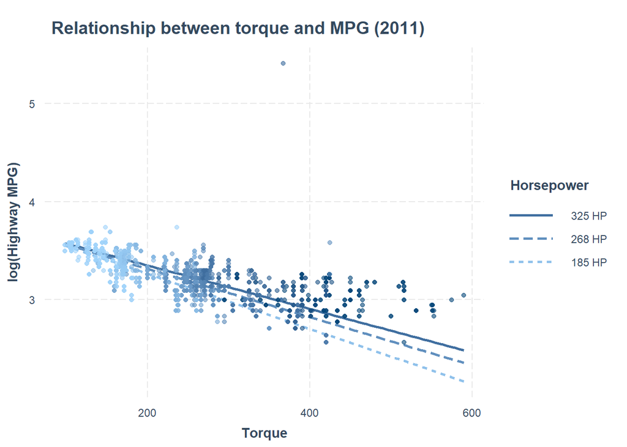

```r
model_interaction_log <- lm(log_Highway_MPG ~ Torque * Horsepower + Height + Length + Width, data = cars_2011_no_outliers)

hp_values <- c(185, 268, 325)  # Here are the values found above.

library(interactions)
#Generate the interaction plot for 2011 cars

interact_plot(model_interaction_log, pred = Torque, modx = Horsepower,
              at = hp_values,  # Use specific horsepower values found above
              plot.points = TRUE,
              main.title = "Relationship between torque and MPG (2011)",
              x.label = "Torque",
              y.label = "log(Highway MPG)",
              legend.main = "Horsepower",
              modx.values = hp_values,  # Explicitly set the horsepower values for the plot
              modx.labels = c("185 HP", "268 HP", "325 HP"))  # Label the values accordingly
```

### (f) Calculate manually

```r
# Create the design matrix.
X <- model.matrix(~ Torque + Horsepower + Height + Length + Width + Year, data = gasoline_cars)

# Create the response vector y
y <- gasoline_cars$log_Highway_MPG

# Calculate the coefficients using matrix algebra
# (X^T X)^{-1} X^T y
beta_manual <- solve(t(X) %*% X) %*% t(X) %*% y

# Display the manual coefficients
cat("Manual coefficients:\n")
```

```
Manual coefficients:
```

```r
print(beta_manual)
```

```
                     [,1]
(Intercept) -5.339592e+01
Torque      -2.305897e-03
Horsepower   9.328547e-04
Height       4.019629e-04
Length       2.989852e-05
Width       -9.177856e-05
Year         2.829937e-02
```

```r
# Compare with the lm() coefficients
beta_lm_log <- coef(model_log)
cat("\nCoefficients from lm() with log_Highway_MPG:\n")
```

```
Coefficients from lm() with log_Highway_MPG:
```

```r
print(beta_lm_log)
```

```
  (Intercept)        Torque    Horsepower        Height        Length
-5.339592e+01 -2.305897e-03  9.328547e-04  4.019629e-04  2.989852e-05
        Width          Year
-9.177856e-05  2.829937e-02
```

As we can see, the manually calculated coefficients and the coefficients from the lm() model match exactly.